© Bản quyền thuộc về Quantopian Inc.  
© Bản quyền sửa đổi thuộc về AI Cafe¹  
Giấy phép [Creative Commons Attribution 4.0](https://creativecommons.org/licenses/by/4.0/legalcode).  
[Khuyến cáo](https://aicafe.one/khuyen-cao/)

# Chọn tập vũ trụ

by Gil Wassermann, Maxwell Margenot

Edited by AI Cafe¹

Việc chọn tập vũ trụ mà một thuật toán giao dịch có thể quan trọng không kém, thậm chí còn hơn cả chiến lược giao dịch. Trong bài giảng này, chúng ta sẽ cùng nhau đi qua những điều cơ bản về việc xây dựng một tập vũ trụ giao dịch.

## Tập vũ trụ là gì?

Ở cấp độ cao, việc chọn tập vũ trụ là quá trình lựa chọn nhóm các chứng khoán mà thuật toán của bạn sẽ giao dịch. Ví dụ, một thuật toán được thiết kế để hoạt động với các đặc điểm của một tập vũ trụ bao gồm các cổ phiếu công nghệ có thể hoạt động rất tốt trong tập vũ trụ đó nhưng lại thất bại ở các lĩnh vực khác. Thí nghiệm với các tập vũ trụ khác nhau bằng cách điều chỉnh các thành phần của chúng là một phần thiết yếu trong việc phát triển một chiến lược giao dịch.

Một ví dụ đơn giản là chúng ta xây dựng tập vũ trụ bao gồm 100 cổ phiếu được giao dịch nhiều nhất trên sàn

```python
# Cài thư viện lấy dữ liệu miễn phí
!curl -fsSLO https://raw.githubusercontent.com/algo-stocks/data/master/data.py
```

```python
from data import load_data
df = load_data()
df = df[df.ticker.str.len() == 3]
```

```python
df.set_index(['date']).loc['2025-04-15'].sort_values('volume', ascending=False).iloc[:100]
```

| date | ticker | open | high | low | close | volume |
| --- | --- | --- | --- | --- | --- | --- |
| 2025-04-15 | SHB | 12.05 | 12.10 | 11.70 | 11.90 | 58398700 |
| 2025-04-15 | VIX | 12.70 | 13.10 | 12.25 | 12.60 | 51452100 |
| 2025-04-15 | HPG | 25.15 | 26.15 | 25.05 | 25.85 | 50570600 |
| 2025-04-15 | MBB | 23.00 | 23.40 | 22.90 | 23.00 | 29512300 |
| 2025-04-15 | VCG | 21.50 | 22.80 | 21.05 | 22.30 | 27635800 |
| ... | ... | ... | ... | ... | ... | ... |
| 2025-04-15 | HDG | 23.40 | 23.85 | 22.60 | 22.80 | 2016500 |
| 2025-04-15 | SCR | 5.70 | 5.79 | 5.58 | 5.62 | 2004000 |
| 2025-04-15 | TIG | 7.20 | 7.40 | 6.70 | 7.00 | 1978462 |
| 2025-04-15 | SSB | 18.60 | 19.10 | 18.10 | 18.60 | 1968800 |
| 2025-04-15 | VGC | 41.00 | 43.45 | 40.15 | 40.85 | 1939400 |

100 rows × 6 columns

Đây là một khởi đầu tốt, nhưng một lần nữa, đây là một tập vũ trụ rất ngây thơ. Khối lượng giao dịch cao cho thấy tính thanh khoản nhưng không nhất thiết chỉ ra một công ty khỏe mạnh, phát triển. Có nhiều yếu tố khác ảnh hưởng đến việc xây dựng một tập vũ trụ tốt.

Trong phần còn lại của bài giảng này, chúng ta sẽ thiết kế vũ trụ của riêng mình. Hãy cùng tạo ra Lectures100!

## Lectures100

### Mức thay đổi (Turnover)

Một yếu tố khác cần xem xét khi thiết kế một tập vũ trụ là tỷ lệ thay đổi của vũ trụ đó. Turnover là một cách để đo lường tỷ lệ thay đổi này. Turnover được định nghĩa là số lượng cổ phiếu vào hoặc ra khỏi tập vũ trụ trong một khoảng thời gian cụ thể.

Hãy tưởng tượng một tập vũ trụ có Turnover bằng 0. Tập vũ trụ này sẽ hoàn toàn không thay đổi trước những biến động của thị trường. Hơn nữa, những cổ phiếu không phù hợp với tập vũ trụ sẽ không bao giờ bị loại bỏ và những cổ phiếu nên được đưa vào sẽ không bao giờ xuất hiện.

Ngược lại, hãy tưởng tượng một tập vũ trụ thay đổi toàn bộ các thành phần của nó mỗi ngày. Một thuật toán được xây dựng trên vũ trụ này sẽ buộc phải bán toàn bộ danh mục đầu tư của mình mỗi ngày. Điều này phát sinh chi phí giao dịch, làm giảm lợi nhuận.

Khi tạo ra một tập vũ trụ, có một sự đánh đổi nội tại giữa sự trì trệ và độ nhạy cảm với thị trường.

Hãy cùng xem xét Turnover cho Lectures100!

```python
volume = df.set_index(['date']).loc['2024-04-15':].reset_index().pivot(index='date', columns='ticker', values='volume')
universe = volume.rank(axis=1, ascending=False) < 101
```

```python
def calculate_daily_turnover(unstacked):
    return universe.diff().sum(axis=1).iloc[1:]

def plot_daily_turnover(universe):

    # Calculate locations where the inclusion state of an asset changed.
    turnover = calculate_daily_turnover(universe)

    # Write the data to an axis.
    ax = turnover.plot(figsize=(14, 8))

    # Add style to the axis.
    ax.grid(False)
    ax.set_title('Changes per Day')
    ax.set_ylabel('Number of Added or Removed Assets')


def print_daily_turnover_stats(universe):
    turnover = calculate_daily_turnover(universe)
    print('Mean', turnover.mean())
    print('Std', turnover.std())
    print('25%', turnover.quantile(0.25))
    print('50%', turnover.quantile(0.5))
    print('75%', turnover.quantile(0.75))
    print('Min', turnover.min())
    print('Max', turnover.max())
```

```
Mean 30.55060728744939
Std 8.367357551457355
25% 26.0
50% 30.0
75% 34.0
Min 14
Max 104
```

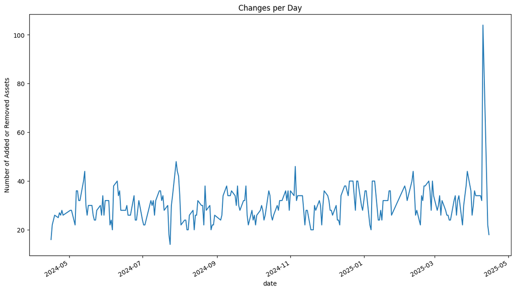

```python
plot_daily_turnover(universe)
print_daily_turnover_stats(universe)
```

Danh sách cổ phiếu thay đổi liên tục hàng ngày với tỷ lệ rất cao, khoảng 30 cổ phiếu vào ra tập vũ trụ hàng ngày, cá biệt có những ngày thay đổi lên đến 100

### Làm mượt danh sách

Để giảm mức Turnover, chúng ta sẽ sử dụng giá trị trung bình của khối lượng giao dịch trong 20 ngày thay vì lấy giá trị gần nhất

```python
universe = volume.fillna(0).rolling(20).mean().dropna(how='all').rank(axis=1, ascending=False) < 101
```

```
Mean 2.5526315789473686
Std 1.6451348927093576
25% 2.0
50% 2.0
75% 4.0
Min 0
Max 6
```

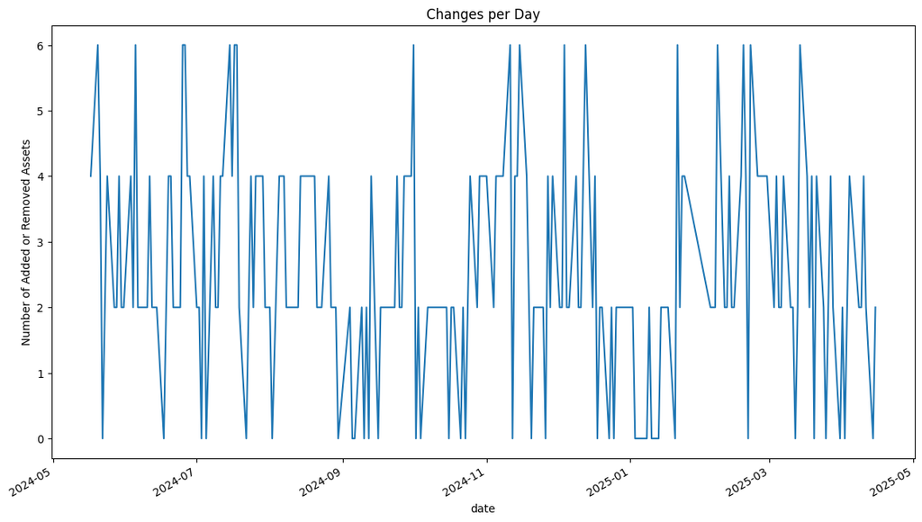

```python
plot_daily_turnover(universe)
print_daily_turnover_stats(universe)
```

Lúc này, tập vũ trụ của chúng ta đã ổn định hơn rất nhiều, với lượng vào ra chỉ tầm 2.5 cổ phiếu một ngày, thấp hơn rất nhiều so với phiên bản trước.

*Lưu ý: Tài liệu này mang tính chất chia sẻ kiến thức khoa học dữ liệu. Các mã chứng khoán xuất hiện trong tài liệu chỉ mang tính chất minh hoạ, không khuyến nghị đầu tư. Chúng tôi không chịu trách nhiệm trước mọi rủi ro nào do sử dụng tài liệu này.*